# phmsa_work

Tiasia Saunders

2025-06-30

# PHMSA Docket 2019-0091: Pipeline Safety: Amendments to Liquefied Natural Gas Facilities Comments Analysis

### PHMSA’s Docket 2019-0091 is an advance notice of proposed rulemaking seeking public input on updating safety regulations for liquefied natural gas (LNG) facilities. The agency aims to modernize outdated rules, incorporate updated industry standards, and address emerging technologies and practices in LNG operations. This process includes evaluating environmental impacts and potential costs and benefits of regulatory changes.

```r
# Load libraries
library(tidyverse)
```

```r
library(tidytext)
library(dplyr)
library(ggplot2)
library(tm)
library(topicmodels)
library(janitor)
library(tm)
library(topicmodels)
library(lda)
library(ldatuning)
library(DT)
library(knitr)
library(kableExtra)
library(reshape2)
library(wordcloud)
library(pals)
library(SnowballC)
library(flextable)
library(rio)
library(spacyr)
library(slam)
spacy_install()
# Load the data

read_csv("phmsa_comments_all_.csv") |>
  clean_names() -> phmsa_comments
```

## Leading States by Number of Comments

```r
state_comments <- phmsa_comments |>
  mutate(state_province = ifelse(state_province %in% state.name,
  state.abb[match(state_province, state.name)], state_province)) |>
  select(state_province) |>
  count(state_province, sort = TRUE)
  print(state_comments)
```

```
## # A tibble: 140 × 2
##    state_province     n
##    <chr>          <int>
##  1 CA              1138
##  2 NY               533
##  3 <NA>             529
##  4 FL               384
##  5 PA               333
##  6 IL               306
##  7 WA               288
##  8 OR               238
##  9 TX               230
## 10 MA               225
## # ℹ 130 more rows
```

- Top 5 states that commented on this docket were the following: CA, NY, FL, PA, and IL. This makes sense considering that CA, PA, and IL are part of the top states that has the most railroads. Additionally, PA and TX are a couple of states that produces the most LNG in the US.

```r
time_comments <- phmsa_comments |>
 select(posted_date, title) |>
  group_by(posted_date) |>
  summarize(comment_count = n())
```

## Graphic of Comments Over Time

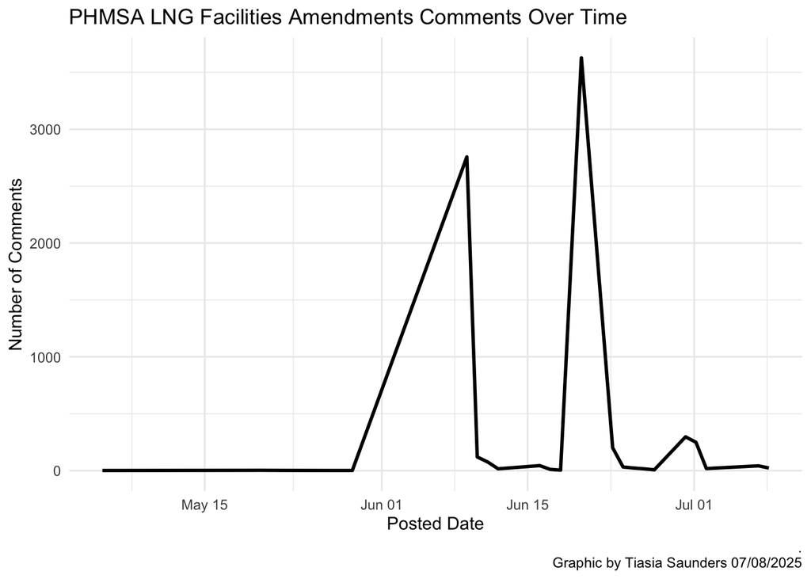

```r
ggplot(time_comments, aes(x = posted_date, y = comment_count)) +
  geom_line(size = 1) +
  labs(
    title = "PHMSA LNG Facilities Amendments Comments Over Time",
    x = "Posted Date",
    y = "Number of Comments",
     caption = ".\nGraphic by Tiasia Saunders 07/08/2025"
  ) +
  theme_minimal()
```

```r
week_before_comments_closed <- phmsa_comments |>
  filter(posted_date >= "2025-07-01")
```

```r
spiked_earlyjune_comments <- phmsa_comments |>
  filter(as.character(posted_date) == "2025-06-09 04:00:00")

spiked_midjune_comments <- phmsa_comments |>
  filter(as.character(posted_date) == "2025-06-20 04:00:00")

spiked_latejune_comments <- phmsa_comments |>
  filter(as.character(posted_date) == "2025-06-30 04:00:00")
```

## Comment Differantion

```r
different_commentors <- phmsa_comments |>
  select(title) |>
  count(title, sort = TRUE)
```

```r
# People: have both first and last names
people <- phmsa_comments |>
  filter(!is.na(first_name) & first_name != "",
         !is.na(last_name) & last_name != "")

# Organizations: missing either first or last name
organizations <- phmsa_comments |>
  filter(is.na(first_name) | first_name == "" |
         is.na(last_name) | last_name == "")
print(organizations)
```

```
## # A tibble: 31 × 13
##    document_id          agency_id document_type     posted_date         title
##    <chr>                <chr>     <chr>             <dttm>              <chr>
##  1 PHMSA-2019-0091-0012 PHMSA     Proposed Rule     2025-05-05 04:00:00 Pipelin…
##  2 PHMSA-2019-0091-0014 PHMSA     Public Submission 2025-05-20 04:00:00 Comment…
##  3 PHMSA-2019-0091-0015 PHMSA     Public Submission 2025-05-20 04:00:00 Comment…
##  4 PHMSA-2019-0091-0016 PHMSA     Public Submission 2025-05-20 04:00:00 Comment…
##  5 PHMSA-2019-0091-0017 PHMSA     Public Submission 2025-05-22 04:00:00 Comment…
##  6 PHMSA-2019-0091-0018 PHMSA     Public Submission 2025-05-22 04:00:00 Comment…
##  7 PHMSA-2019-0091-0019 PHMSA     Public Submission 2025-05-27 04:00:00 Comment…
##  8 PHMSA-2019-0091-0020 PHMSA     Public Submission 2025-05-28 04:00:00 Comment…
##  9 PHMSA-2019-0091-6879 PHMSA     Public Submission 2025-06-23 04:00:00 Comment…
## 10 PHMSA-2019-0091-7257 PHMSA     Public Submission 2025-07-01 04:00:00 Comment…
## # ℹ 21 more rows
## # ℹ 8 more variables: received_date <dttm>, first_name <chr>, last_name <chr>,
## #   city <chr>, state_province <chr>, zip_postal_code <chr>, country <chr>,
## #   comment <chr>
```

#### Organization Submissions Results Analysis:

- Organization Submissions came from multiple organizations including [Pipeline Safety Trust](https://pstrust.org/), an org dedicating to keep communities and environments safe from pipeline hazards and RESTORE, [Restore Explicit Symmetry to our Ravaged Earth](https://chorusfoundation.org/what-we-fund/restore-restore-explicit-symmetry-to-our-ravaged-earth-trust/), an organization that strive to raise public, governmental, and corporate awareness about the necessity to return to a sustainable equilibrium.
- Pipeline Safety Trust’s comment included an attachment in which they request a 60-day extension of the comment period for PHMSA’s ANPRMS Docket 2019-0091 and Docket 2025-0019, citing the need for more time to review the complex issues, discuss with stakeholders, and provide meaningful input. They emphasize the importance of public safety and the need for thorough consideration of the proposed amendments to LNG facilities regulations.
- Other organizations include BLUE Engineering and Consulting, GPA Midstream Association, We Act for Environmental Justice, National Association of Pipeline Safety Representatives, Center for Biological Diversity Food & Water Watch, Science and Environmental Health Network, Micah Six Eight Mission, Cheniere Energy, Earthjustice, Environmental Defense Fund, National Grid, Eversource Energy, Sempra Infrastructure Partners, LP, South Texas Environmental Justice Network, American Petroleum Institute, Center for LNG, Interstate Natural Gas Association of America, AGA, APGA, NGA, The Williams Companies, Inc., Pipeline Safety Trust, Southwest Gas Corporation, CH·IV International, GTT North America
- It was 31 comments from these organizations
- The organization commentators strongly emphasize the urgent need to revise outdated LNG safety regulations, citing unresolved risks and inadequate, secretive modeling that threatens public safety, especially in Southwest Louisiana’s LNG terminal zones. They highlight past workshops and expert recommendations that PHMSA has yet to fully address or make publicly available, including important test results from facilities like the LGFSTF. Concerns are raised about transparency, the influence of industry-aligned institutions, and the lack of meaningful community involvement in the regulatory process. Several comments also point to recent reports and real-world risks, including insurance companies withdrawing support due to underestimated dangers. Overall, they demand that PHMSA prioritize safety, transparency, and scientifically validated standards before proceeding with any rule revisions.

```r
same_earthworks_message <- phmsa_comments |>
  filter(str_detect(comment, fixed("Dear Director Duffy,")))

same_other_message <- phmsa_comments |>
  filter(str_detect(comment, fixed("I am writing,")))
```

## Sentiment Analysis

```r
#Tokenizing data
phmsa_comments <- phmsa_comments %>%
  mutate(clean_comment = str_replace_all(comment, "- ", ""))
tokenized_df <- tibble(
  comment = phmsa_comments$clean_comment
)
tokenized_comments <- phmsa_comments %>%
  select(clean_comment) %>%
  unnest_tokens(word, clean_comment)

tokenized_comments
```

```
## # A tibble: 1,679,612 × 1
##    word
##    <chr>
##  1 <NA>
##  2 lng
##  3 is
##  4 a
##  5 polluting
##  6 fossil
##  7 fuel
##  8 the
##  9 benefits
## 10 of
## # ℹ 1,679,602 more rows
```

```r
# Removing stop words
tokenized_comments <- tokenized_comments |>
 anti_join(stop_words, by = c("word" = "word"))
```

```r
# Creating Bigrams
lng_bigrams <- tokenized_df |>
  unnest_tokens(bigram, comment, token="ngrams", n=2)

lng_bigrams
```

```
## # A tibble: 1,672,017 × 1
##    bigram
##    <chr>
##  1 <NA>
##  2 lng is
##  3 is a
##  4 a polluting
##  5 polluting fossil
##  6 fossil fuel
##  7 fuel the
##  8 the benefits
##  9 benefits of
## 10 of reducing
## # ℹ 1,672,007 more rows
```

```r
#Filter out stop words.

lng_bigrams1 <- lng_bigrams |>
  separate(bigram, c("word1", "word2"), sep = " ")

lng_filtered_bigrams <- lng_bigrams1 |>
  filter(!word1 %in% stop_words$word) |>
  filter(!word2 %in% stop_words$word) |>
    filter(!is.na(word1)) |>
     filter(!is.na(word2))

lng_counted_bigrams <- lng_filtered_bigrams |>
  count(word1, word2, sort = TRUE)
```

```r
# Top twenty bigrams
top_twenty_bigrams <- lng_counted_bigrams |>
  arrange(desc(n), word1, word2) |>
  head(20)

top_twenty_bigrams
```

```
## # A tibble: 20 × 3
##    word1     word2              n
##    <chr>     <chr>          <int>
##  1 lng       export         11717
##  2 protect   workers        11423
##  3 methane   gas            11171
##  4 lng       infrastructure 11119
##  5 pipeline  infrastructure 10897
##  6 export    terminals       7817
##  7 safety    rules           7811
##  8 safety    regulations     7563
##  9 public    safety          7538
## 10 require   updates         7515
## 11 urgently  require         7515
## 12 deeply    concerned       7504
## 13 gas       pipeline        7265
## 14 hazardous materials       4747
## 15 materials safety          4746
## 16 safety    standards       3915
## 17 fossil    fuel            3911
## 18 lng       facilities      3911
## 19 safety    administration  3911
## 20 gas       lng             3910
```

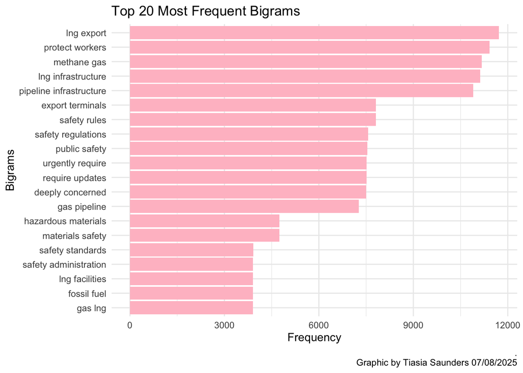

```r
# Combine the bigram into one string for labeling
top_twenty_bigrams <- lng_counted_bigrams |>
  arrange(desc(n), word1, word2) |>
  head(20) |>
  mutate(bigrams = paste(word1, word2))

ggplot(top_twenty_bigrams, aes(x = reorder(bigrams, n), y = n)) +
  geom_col(fill = "pink") +
  coord_flip() +
  labs(
    title = "Top 20 Most Frequent Bigrams",
    x = "Bigrams",
    y = "Frequency",
      caption = ".\nGraphic by Tiasia Saunders 07/08/2025"
  ) +
  theme_minimal()
```

- The top five most frequent bigrams are the following: lng export, protect workers, methane gas, lng infrastructure, and pipeline infrastructure. This suggests that the public is concerned about the safety and infrastructure of LNG facilities, as well as the impact on workers. The bigrams also suggest that the public is concerned about the environmental impact of LNG facilities, particularly in relation to methane gas emissions.

```r
nrc_sentiments <- get_sentiments("nrc")
afinn_sentiments <- get_sentiments("afinn")
```

```r
sentiments_comments <- tokenized_comments |>
  inner_join(nrc_sentiments, by = "word")
  overall_sentiment_count <- sentiments_comments |>
  count(sentiment) |>
  arrange(desc(n))
```

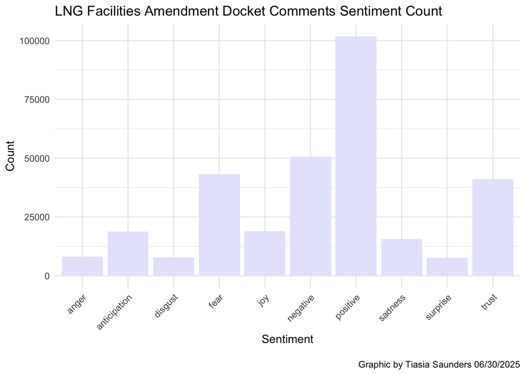

```r
ggplot(overall_sentiment_count, aes(x = sentiment, y = n)) +
  geom_bar(stat = "identity", position = "dodge", fill = "lavender") +
  labs(
    title = "LNG Facilities Amendment Docket Comments Sentiment Count",
    x = "Sentiment",
    y = "Count",
      caption = "\nGraphic by Tiasia Saunders 06/30/2025"
  ) +
  theme_minimal() +
  theme(axis.text.x = element_text(angle = 45, hjust = 1))
```

- The most common sentiment of the comments is positive, suggesting that the public is generally supportive of the proposed amendments to LNG facilities.
- The second most common sentiment is negative, indicating that there are some concerns about the proposed amendments.
- The third most common sentiment is fear, suggesting that there are some fears about the potential impact of the proposed amendments on LNG facilities.
- The fourth common sentiment is trust, indicating that there are some concerns about the trustworthiness of the proposed amendments.

## Leading Positive, Negative, Fear, and Trust Sentiments

```r
overall_negative_count <- sentiments_comments |>
   filter(sentiment == "negative") |>
  count(sentiment,word) |>
  arrange(desc(n))

print(overall_negative_count)
```

```
## # A tibble: 333 × 3
##    sentiment word            n
##    <chr>     <chr>       <int>
##  1 negative  dangerous   11438
##  2 negative  leakage      7265
##  3 negative  hazardous    4754
##  4 negative  government   3914
##  5 negative  reject       3907
##  6 negative  wrong        3895
##  7 negative  devastating  3893
##  8 negative  pollution    3642
##  9 negative  explosion    3638
## 10 negative  avoid        3633
## # ℹ 323 more rows
```

```r
overall_positive_count <- sentiments_comments |>
   filter(sentiment == "positive") |>
  count(sentiment,word) |>
  arrange(desc(n))

print(overall_positive_count)
```

```
## # A tibble: 381 × 3
##    sentiment word              n
##    <chr>     <chr>         <int>
##  1 positive  protect       15377
##  2 positive  effective     11154
##  3 positive  public         7567
##  4 positive  community      7545
##  5 positive  strengthen     3919
##  6 positive  advanced       3903
##  7 positive  strengthening  3900
##  8 positive  fulfill        3899
##  9 positive  center         3897
## 10 positive  savings        3896
## # ℹ 371 more rows
```

```r
overall_fear_sentiment <- sentiments_comments |>
  filter(sentiment == "fear") |>
  count(sentiment,word) |>
  arrange(desc(n))
  print(overall_fear_sentiment)
```

```
## # A tibble: 191 × 3
##    sentiment word            n
##    <chr>     <chr>       <int>
##  1 fear      dangerous   11438
##  2 fear      concerned    7533
##  3 fear      hazardous    4754
##  4 fear      government   3914
##  5 fear      reject       3907
##  6 fear      devastating  3893
##  7 fear      explosion    3638
##  8 fear      avoid        3633
##  9 fear      risk           34
## 10 fear      fire           23
## # ℹ 181 more rows
```

```r
overall_trust_sentiment <- sentiments_comments |>
  filter(sentiment =="trust") |>
  count(sentiment,word) |>
  arrange(desc(n))
print(overall_trust_sentiment)
```

```
## # A tibble: 228 × 3
##    sentiment word               n
##    <chr>     <chr>          <int>
##  1 trust     effective      11154
##  2 trust     strengthening   3900
##  3 trust     center          3897
##  4 trust     devastating     3893
##  5 trust     safe            3654
##  6 trust     accountability  3635
##  7 trust     guidance        3634
##  8 trust     improve         3629
##  9 trust     director        2969
## 10 trust     carol             32
## # ℹ 218 more rows
```

## Sentiment Analysis Breakdown

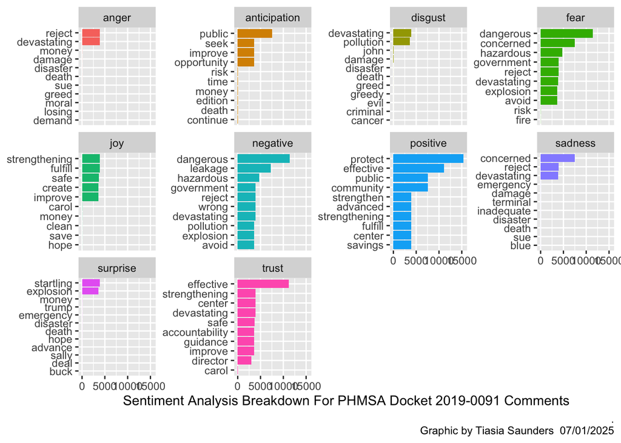

```r
sentiments_comments %>%
  count(sentiment, word) %>%
  group_by(sentiment) %>%
  slice_max(n, n = 10) %>%
  ungroup() %>%
  mutate(word = reorder_within(word, n, sentiment)) %>%
  ggplot(aes(n, word, fill = sentiment)) +
  geom_col(show.legend = FALSE) +
  facet_wrap(~sentiment, scales = "free_y") +
  scale_y_reordered() +
  labs(
    x = "Sentiment Analysis Breakdown For PHMSA Docket 2019-0091 Comments",
    y = NULL,
    caption = ".\nGraphic by Tiasia Saunders  07/01/2025"
  )
```

- The top five positive sentiments are: protect, effective, public, community, and strengthen which suggests that the public is generally supportive of the proposed amendments to LNG facilities. The public is concerned about the safety and effectiveness of LNG facilities, as well as the impact on the community. The public is also concerned about the strength of the proposed amendments and their potential impact on LNG facilities.
- The top five negative sentiments are: dangerous, leakage, hazardous, government, and reject, which suggests that the public is concerned about the potential dangers and hazards of LNG facilities. The public is also concerned about the government’s role in regulating LNG facilities and the potential for LNG facilities to be rejected by the public.
- The top five fear sentiments are: dangerous, concerned, hazardous, government, and reject, which suggests that the public is concerned about the potential dangers and hazards of LNG facilities. The public is also concerned about the government’s role in regulating LNG facilities and the potential for LNG facilities to be rejected by the public.
- The top five trust sentiments are: effective, strengthening, center, devastating, and safe, which suggests that the public is concerned about the overall effectiveness of the proposed LNG facilities amendments. Additionally, the public is concerned about the potential for LNG facilities to be strengthened and made safer. The public is also concerned about the potential for LNG facilities to be devastating to the environment and the community.

## Topic Modeling

```r
textdata <- phmsa_comments |>

  select(document_id, posted_date, title, first_name, last_name, comment) |>
  as.data.frame() |>
  rename(doc_id = document_id, text = comment)

# load stopwords
english_stopwords <- readLines("https://slcladal.github.io/resources/stopwords_en.txt", encoding = "UTF-8")
# create corpus object
corpus <- Corpus(DataframeSource(textdata))
# Preprocessing chain
processedCorpus <- tm_map(corpus, content_transformer(tolower))
processedCorpus <- tm_map(processedCorpus, removeWords, english_stopwords)
processedCorpus <- tm_map(processedCorpus, removePunctuation, preserve_intra_word_dashes = TRUE)
processedCorpus <- tm_map(processedCorpus, removeNumbers)
processedCorpus <- tm_map(processedCorpus, stemDocument, language = "en")
processedCorpus <- tm_map(processedCorpus, stripWhitespace)
```

```r
#DTM: rows correspond to the documents in the corpus. Columns correspond to the terms in the documents. Cells correspond to the weights of the terms. (Girder)
# compute document term matrix with terms >= minimumFrequency
minimumFrequency <- 5
DTM <- DocumentTermMatrix(processedCorpus, control = list(bounds = list(global = c(minimumFrequency, Inf))))
# have a look at the number of documents and terms in the matrix
dim(DTM)
```

```
## [1] 7596  671
```

```r
# due to vocabulary pruning, we have empty rows in our DTM
# LDA does not like this. So we remove those docs from the
# DTM and the metadata
sel_idx <- slam::row_sums(DTM) > 0
DTM <- DTM[sel_idx, ]
textdata <- textdata[sel_idx, ]
#5 term minimum[1] 1387 3019
#5 term minimum[1] 308597 10339
```

```r
K <- 6
# set random number generator seed
set.seed(9161)
#Latent Dirichlet Allocation, LDA
topicModel2 <- LDA(DTM, K, method="Gibbs", control=list(iter = 500, verbose = 25, alpha = 0.2))
```

```
## K = 6; V = 671; M = 7595
## Sampling 500 iterations!
## Iteration 25 ...
## Iteration 50 ...
## Iteration 75 ...
## Iteration 100 ...
## Iteration 125 ...
## Iteration 150 ...
## Iteration 175 ...
## Iteration 200 ...
## Iteration 225 ...
## Iteration 250 ...
## Iteration 275 ...
## Iteration 300 ...
## Iteration 325 ...
## Iteration 350 ...
## Iteration 375 ...
## Iteration 400 ...
## Iteration 425 ...
## Iteration 450 ...
## Iteration 475 ...
## Iteration 500 ...
## Gibbs sampling completed!
```

```r
tmResult <- posterior(topicModel2)
theta <- tmResult$topics
beta <- tmResult$terms
topicNames <- apply(terms(topicModel2, 10), 2, paste, collapse = " ")  # reset topicnames
```

```r
# Step 1: Check dimensions
# Ensure doc_id and rownames are character
rownames(theta) <- as.character(rownames(theta))
textdata$doc_id <- as.character(textdata$doc_id)

# Get common document IDs
common_ids <- intersect(rownames(theta), textdata$doc_id)

# Filter both datasets to only include common documents
theta_aligned <- theta[rownames(theta) %in% common_ids, ]
textdata_filtered <- textdata[textdata$doc_id %in% common_ids, ]

# Reorder textdata_filtered to match theta_aligned
textdata_filtered <- textdata_filtered[match(rownames(theta_aligned), textdata_filtered$doc_id), ]

# Check that everything lines up
if (!all(rownames(theta_aligned) == textdata_filtered$doc_id)) {
  stop("The document IDs still do not match. Please check the data alignment.")
}

# Print dimensions
n_theta <- nrow(theta_aligned)
n_textdata_filtered <- nrow(textdata_filtered)
cat("Number of aligned theta rows: ", n_theta, "\n")
```

```
## Number of aligned theta rows:  7595
```

```r
cat("Number of aligned textdata rows: ", n_textdata_filtered, "\n")
```

```
## Number of aligned textdata rows:  7595
```

```r
# Combine data
topic_data <- data.frame(theta_aligned, text = textdata_filtered$text)

# Aggregate topic proportions by dom_vs_intl
topic_proportion_per_category <- aggregate(. ~ text, data = topic_data, FUN = mean)

# Rename topic columns (assuming K and topicNames are defined)
colnames(topic_proportion_per_category)[2:(K+1)] <- topicNames

# Reshape for visualization
vizDataFrame <- melt(topic_proportion_per_category, id.vars = "text")

# Optionally filter out a decade if needed
# vizDataFrame <- subset(vizDataFrame, decade != 1960)
```

#### Examine topic names

```r
#enframe(): Converts a named list into a dataframe.
topics <- enframe(topicNames, name = "number", value = "text") %>%
  unnest(cols = c(text))

topics
```

```
## # A tibble: 6 × 2
##   number  text
##   <chr>   <chr>
## 1 Topic 1 pipelin infrastructur communiti safeti lng seek updat methan effect g…
## 2 Topic 2 lng safeti phmsa regul protect communiti industri standard pipelin re…
## 3 Topic 3 administr safeti pipelin phmsa materi infrastructur hazard lng commun…
## 4 Topic 4 safeti lng communiti export protect worker hazard phmsa infrastructur…
## 5 Topic 5 pipelin infrastructur communiti safeti lng seek methan gas effect upd…
## 6 Topic 6 safeti lng communiti export protect worker hazard infrastructur phmsa…
```

### Topic Keywords and Assigned Categories

[output not shown]

```r
# Add categories based on topic keywords
vizDataFrame <- vizDataFrame |>
  mutate(category = case_when(
    str_detect(str_squish(variable), "pipelin infrastructur communiti safeti lng seek updat methan effect gas") ~ "pipeline_safety_update",
    str_detect(str_squish(variable), "lng safeti phmsa regul protect communiti industri standard pipelin requir") ~ "lng_safety_and_labor",
    str_detect(str_squish(variable), "administr safeti pipelin phmsa materi infrastructur hazard lng communiti worker") ~ "hazardous_materials_admin",
    str_detect(str_squish(variable), "pipelin infrastructur communiti safeti lng seek methan gas effect updat") ~ "methane_gas_infrastructure",
    str_detect(str_squish(variable), "safeti lng communiti export protect worker hazard infrastructur phmsa strengthen") ~ "lng_export_prioritization",
    str_detect(str_squish(variable), "safeti lng communiti export protect worker hazard phmsa infrastructur center",) ~ "phmsa_terminal_regulation",
    TRUE ~ "other"
  ))
```

```r
theta2 <- as.data.frame(theta)

topic1 <- theta2 %>%
  rownames_to_column(var = "file") |> # putting the rownames into a new column called file
  mutate(file = str_remove(file, "^X"),  # Remove leading 'X'
         line = str_extract(file, "(?<=\\.txt)\\.\\d+")) |>   # Extract number after .txt
  mutate(file = str_remove(file, "\\.\\d+$")) |>
  rename(topic1 = '1') |> # looking at first topic: pipelin infrastructur communiti lng safeti seek updat effect gas methan
  top_n(20, topic1) |>
  arrange(desc(topic1)) |>
  select(file, line, topic1)
```

```r
# Assuming `theta` is a dataframe related
theta2 <- as.data.frame(theta)

phmsa_topic <- theta2 %>%
  rename(phmsa_topic = '2') %>%
  top_n(20, phmsa_topic) %>%
  arrange(desc(phmsa_topic)) %>%
  select(phmsa_topic)

# Apply rownames_to_column to include story IDs
phmsa_topic <- tibble::rownames_to_column(phmsa_topic, "story_id")

# Clean up story_id if necessary (e.g., removing "X" or other unwanted characters)
phmsa_topic$story_id <- gsub("X", "", phmsa_topic$story_id)

# Check the top 20 story IDs
head(phmsa_topic$story_id, 20)
```

```
##  [1] "PHMSA-2019-0091-6027" "PHMSA-2019-0091-7559" "PHMSA-2019-0091-7560"
##  [4] "PHMSA-2019-0091-7257" "PHMSA-2019-0091-7598" "PHMSA-2019-0091-7586"
##  [7] "PHMSA-2019-0091-0019" "PHMSA-2019-0091-7558" "PHMSA-2019-0091-7570"
## [10] "PHMSA-2019-0091-7584" "PHMSA-2019-0091-0016" "PHMSA-2019-0091-0015"
## [13] "PHMSA-2019-0091-7583" "PHMSA-2019-0091-0014" "PHMSA-2019-0091-4361"
## [16] "PHMSA-2019-0091-7606" "PHMSA-2019-0091-7609" "PHMSA-2019-0091-7587"
## [19] "PHMSA-2019-0091-7503" "PHMSA-2019-0091-6879"
```

```r
# Now it’s validated for PHMSA topics
```

```r
dominantTopics <- vizDataFrame |>
  group_by(text) |>
  slice_max(value, n = 1) |>   # Keep only the topic with highest probability
  ungroup()
```

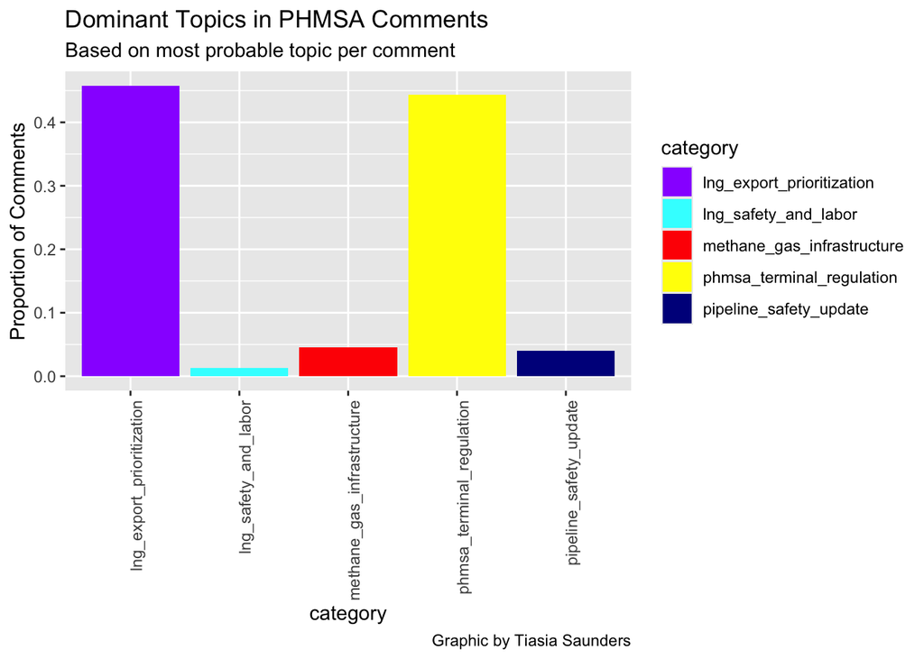

```r
dominantTopics |>
  count(category) |>
  mutate(proportion = n / sum(n)) |>
  ggplot(aes(x = category, y = proportion, fill = category)) +
  geom_bar(stat = "identity") +
  ylab("Proportion of Comments") +
  labs(
    title = "Dominant Topics in PHMSA Comments",
    subtitle = "Based on most probable topic per comment",
    caption = "Graphic by Tiasia Saunders"
  ) +
  scale_fill_manual(
    values = c("#9933FF", "#33FFFF", "red", "yellow", "darkblue", "lavender")
  ) +
  theme(axis.text.x = element_text(angle = 90, hjust = 1))
```

# PHMSA Docket 2025-0032: Hazardous Materials: Mandatory Regulatory Reviews To Unleash American Energy and Improve Government Efficiency Analysis

## This is a preliminary analysis until the docket comments end on 08/04

```r
read_csv("phmsa_2025_0032_comments.csv") |>
  clean_names() -> phmsa_2025_0032_comments
state_2025_0032_comments <- phmsa_2025_0032_comments |>
  mutate(state_province = ifelse(state_province %in% state.name,
  state.abb[match(state_province, state.name)], state_province)) |>
  select(state_province) |>
  count(state_province, sort = TRUE)
  print(state_2025_0032_comments)
```

```
## # A tibble: 52 × 2
##    state_province     n
##    <chr>          <int>
##  1 <NA>             542
##  2 NY               214
##  3 PA               168
##  4 NJ               159
##  5 CA               138
##  6 FL                89
##  7 WA                53
##  8 IL                43
##  9 CO                33
## 10 MI                29
## # ℹ 42 more rows
```

- So, the top five states underneath the PHMSA docket 2025-0032 are the following: New York, Pennslyvania, New Jersey, California and Florida.

```r
time_2025_0032_comments <- phmsa_2025_0032_comments |>
 select(posted_date, title) |>
  group_by(posted_date) |>
  summarize(comment_count = n())
```

## Graphic of Comments Timeline

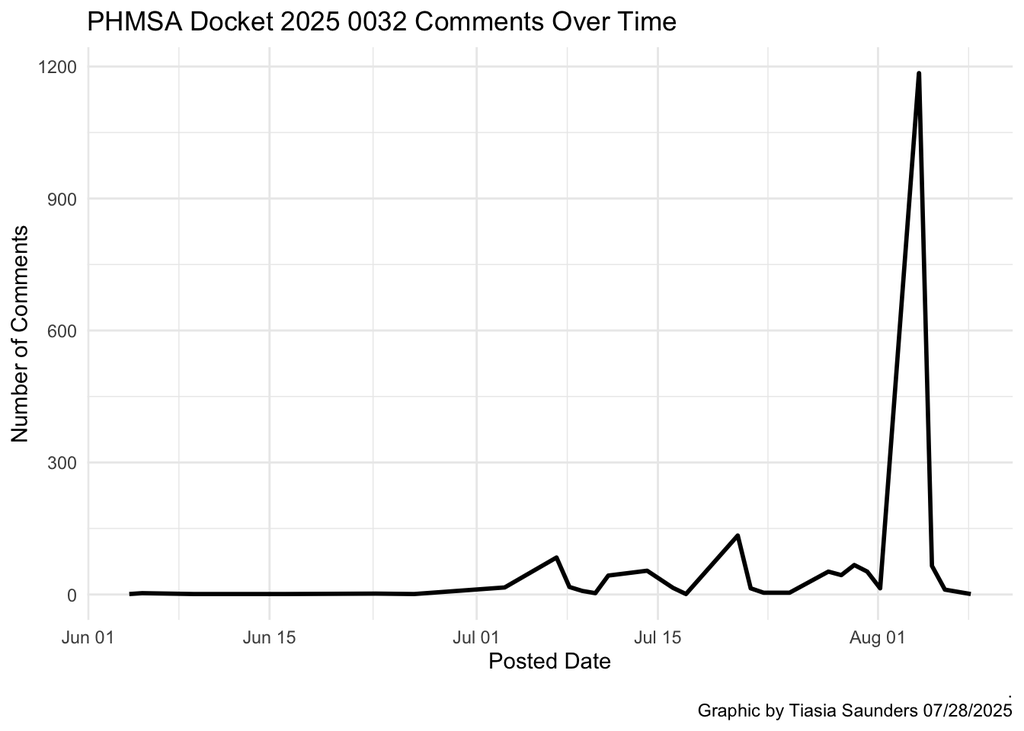

```r
ggplot(time_2025_0032_comments, aes(x = posted_date, y = comment_count)) +
  geom_line(size = 1) +
  labs(
    title = "PHMSA Docket 2025 0032 Comments Over Time",
    x = "Posted Date",
    y = "Number of Comments",
     caption = ".\nGraphic by Tiasia Saunders 07/28/2025"
  ) +
  theme_minimal()
```

```r
multiple_comments <- phmsa_2025_0032_comments |>
  filter(as.character(posted_date) == "2025-08-04 04:00:00")
```

- These comments are all the same so I am assuming they came from a mass submission box which I can try to locate.

## People Versus Organizations

```r
# People: have both first and last names
people_2025_0032 <- phmsa_2025_0032_comments |>
  filter(!is.na(first_name) & first_name != "",
         !is.na(last_name) & last_name != "")

# Organizations: missing either first or last name
organizations_2025_0032 <- phmsa_2025_0032_comments |>
  filter(is.na(first_name) | first_name == "" |
         is.na(last_name) | last_name == "")
print(organizations)
```

[output not shown]

## Sentiment Analysis

```r
#Tokenizing data
phmsa_2025_0032_comments <- phmsa_2025_0032_comments %>%
  mutate(clean_comment = str_replace_all(comment, "- ", ""))
tokenized_2025_0032_df <- tibble(
  comment = phmsa_2025_0032_comments$clean_comment
)
tokenized_2025_0032_comments <- phmsa_2025_0032_comments %>%
  select(clean_comment) %>%
  unnest_tokens(word, clean_comment)

tokenized_2025_0032_comments
```

```
## # A tibble: 447,830 × 1
##    word
##    <chr>
##  1 <NA>
##  2 phmsa
##  3 2025
##  4 0032
##  5 this
##  6 effort
##  7 to
##  8 improve
##  9 government
## 10 efficiency
## # ℹ 447,820 more rows
```

```r
# Removing stop words
tokenized_2025_0032_comments <- tokenized_2025_0032_comments |>
 anti_join(stop_words, by = c("word" = "word"))
```

```r
# Creating Bigrams
lng_2025_0032_bigrams <- tokenized_2025_0032_df |>
  unnest_tokens(bigram, comment, token="ngrams", n=2)

lng_2025_0032_bigrams
```

```
## # A tibble: 445,930 × 1
##    bigram
##    <chr>
##  1 <NA>
##  2 phmsa 2025
##  3 2025 0032
##  4 0032 this
##  5 this effort
##  6 effort to
##  7 to improve
##  8 improve government
##  9 government efficiency
## 10 efficiency is
## # ℹ 445,920 more rows
```

```r
#Filter out stop words.

lng_2025_0032_bigrams1 <- lng_2025_0032_bigrams |>
  separate(bigram, c("word1", "word2"), sep = " ")

lng_filtered_2025_0032_bigrams <- lng_2025_0032_bigrams1 |>
  filter(!word1 %in% stop_words$word) |>
  filter(!word2 %in% stop_words$word) |>
    filter(!is.na(word1)) |>
     filter(!is.na(word2))

lng_2025_0032_counted_bigrams <- lng_filtered_2025_0032_bigrams |>
  count(word1, word2, sort = TRUE)
```

```r
top_twenty_2025_bigrams <- lng_2025_0032_counted_bigrams |>
  arrange(desc(n), word1, word2) |>
  head(20)

top_twenty_2025_bigrams
```

```
## # A tibble: 20 × 3
##    word1        word2           n
##    <chr>        <chr>       <int>
##  1 hazardous    materials    3633
##  2 rail         car          2606
##  3 49           cfr          2351
##  4 natural      gas          1298
##  5 lng          exports      1267
##  6 transport    lng          1248
##  7 liquefied    natural      1242
##  8 gas          lng          1239
##  9 lng          transport    1224
## 10 toxic        chemicals    1214
## 11 east         palestine    1197
## 12 palestine    ohio         1185
## 13 materials    regulations  1174
## 14 program      procedures   1172
## 15 transporting lng          1172
## 16 materials    program      1171
## 17 bulk         transport    1170
## 18 regulations  49           1170
## 19 section      24           1170
## 20 180          section      1169
```

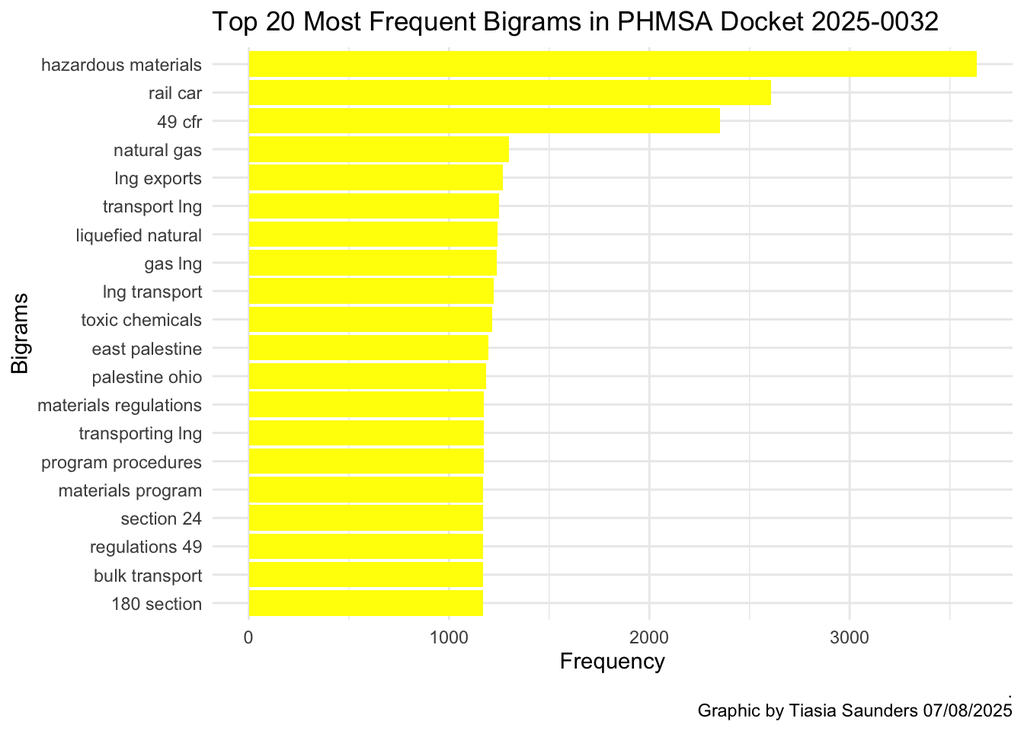

```r
top_twenty_2025_bigrams <- lng_2025_0032_counted_bigrams |>
  arrange(desc(n), word1, word2) |>
  head(20) |>
  mutate(bigrams = paste(word1, word2))

ggplot(top_twenty_2025_bigrams, aes(x = reorder(bigrams, n), y = n)) +
  geom_col(fill = "yellow") +
  coord_flip() +
  labs(
    title = "Top 20 Most Frequent Bigrams in PHMSA Docket 2025-0032",
    x = "Bigrams",
    y = "Frequency",
      caption = ".\nGraphic by Tiasia Saunders 07/08/2025"
  ) +
  theme_minimal()
```

- The top five bigrams from the PHMSA 2025_0032 docket comments are the following: hazardous materials, rail car, 49 cfr, natural gas, and lng exports.

```r
nrc_sentiments <- get_sentiments("nrc")
afinn_sentiments <- get_sentiments("afinn")
```

```r
sentiments_2025_comments <- tokenized_2025_0032_comments |>
  inner_join(nrc_sentiments, by = "word")
  overall_sentiment_count_2025 <- sentiments_2025_comments |>
  count(sentiment) |>
  arrange(desc(n))
```

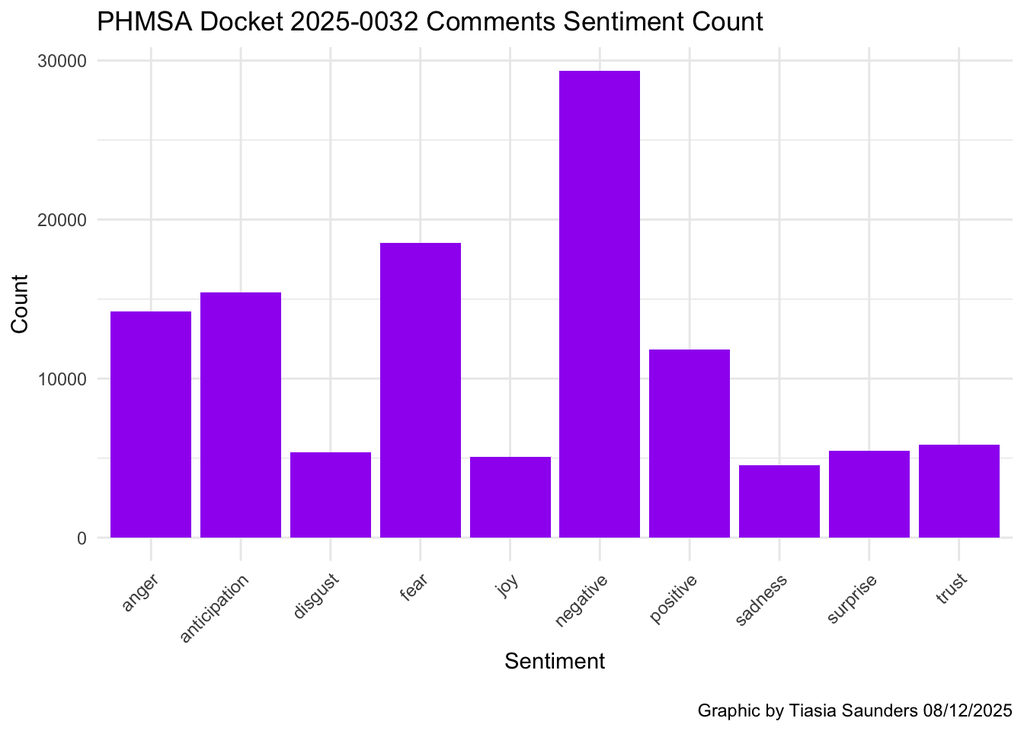

```r
ggplot(overall_sentiment_count_2025, aes(x = sentiment, y = n)) +
  geom_bar(stat = "identity", position = "dodge", fill = "purple") +
  labs(
    title = "PHMSA Docket 2025-0032 Comments Sentiment Count",
    x = "Sentiment",
    y = "Count",
      caption = "\nGraphic by Tiasia Saunders 08/12/2025"
  ) +
  theme_minimal() +
  theme(axis.text.x = element_text(angle = 45, hjust = 1))
```

## Leading Positive, Negative, Fear, and Trust Sentiments

```r
overall_negative_2025_count <- sentiments_2025_comments |>
   filter(sentiment == "negative") |>
  count(sentiment,word) |>
  arrange(desc(n))

print(overall_negative_2025_count)
```

```
## # A tibble: 362 × 3
##    sentiment word            n
##    <chr>     <chr>       <int>
##  1 negative  rail         6866
##  2 negative  hazardous    3786
##  3 negative  ban          2399
##  4 negative  explosion    1428
##  5 negative  dangerous    1338
##  6 negative  accident     1325
##  7 negative  toxic        1240
##  8 negative  disaster     1203
##  9 negative  oppose       1197
## 10 negative  prohibition  1169
## # ℹ 352 more rows
```

```r
overall_positive_2025_count <- sentiments_2025_comments |>
  filter(sentiment == "positive") |>
  count(sentiment, word) |>
  arrange(desc(n))

print(overall_positive_2025_count)
```

```
## # A tibble: 390 × 3
##    sentiment word          n
##    <chr>     <chr>     <int>
##  1 positive  powerful   2281
##  2 positive  primary    1189
##  3 positive  lead       1172
##  4 positive  major      1166
##  5 positive  income     1162
##  6 positive  retention  1158
##  7 positive  fulfill    1157
##  8 positive  public      198
##  9 positive  protect     163
## 10 positive  apt          95
## # ℹ 380 more rows
```

```r
overall_fear_2025_sentiment <- sentiments_2025_comments |>
  filter(sentiment == "fear") |>
  count(sentiment, word) |>
 arrange(desc(n))

print(overall_fear_2025_sentiment)
```

```
## # A tibble: 203 × 3
##    sentiment word          n
##    <chr>     <chr>     <int>
##  1 fear      hazardous  3786
##  2 fear      powerful   2281
##  3 fear      explosion  1428
##  4 fear      dangerous  1338
##  5 fear      accident   1325
##  6 fear      disaster   1203
##  7 fear      change     1160
##  8 fear      fear       1160
##  9 fear      operation  1156
## 10 fear      prevent    1111
## # ℹ 193 more rows
```

```r
overall_trust_2025_sentiment <-sentiments_2025_comments |>
  filter(sentiment == "trust") |>
  count(sentiment, word) |>
  arrange(desc(n))

print(overall_trust_2025_sentiment)
```

```
## # A tibble: 215 × 3
##    sentiment word          n
##    <chr>     <chr>     <int>
##  1 trust     powerful   2281
##  2 trust     income     1162
##  3 trust     operation  1156
##  4 trust     rule        215
##  5 trust     forecast     84
##  6 trust     ground       65
##  7 trust     manage       64
##  8 trust     resources    62
##  9 trust     larger       58
## 10 trust     continue     53
## # ℹ 205 more rows
```

## PHMSA Docket 2025-0032 Sentiment Analysis Breakdown

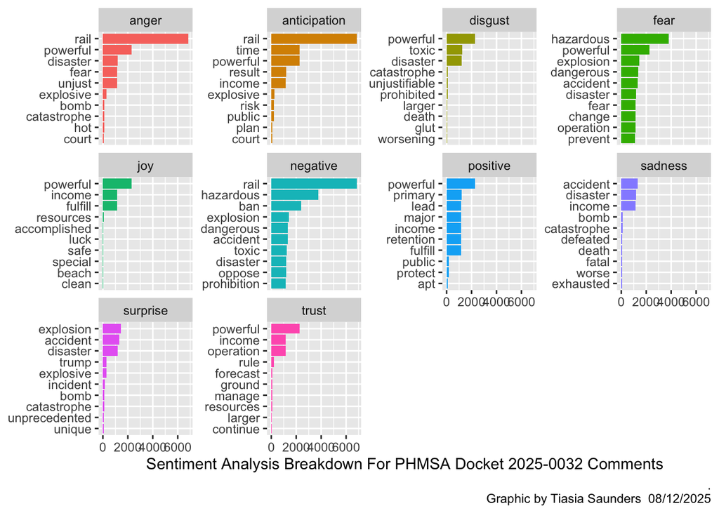

```r
sentiments_2025_comments %>%
  count(sentiment, word) %>%
  group_by(sentiment) %>%
  slice_max(n, n = 10) %>%
  ungroup() %>%
  mutate(word = reorder_within(word, n, sentiment)) %>%
  ggplot(aes(n, word, fill = sentiment)) +
  geom_col(show.legend = FALSE) +
  facet_wrap(~sentiment, scales = "free_y") +
  scale_y_reordered() +
  labs(
    x = "Sentiment Analysis Breakdown For PHMSA Docket 2025-0032 Comments",
    y = NULL,
    caption = ".\nGraphic by Tiasia Saunders  08/12/2025"
  )
```

## Topic Modeling

```r
textdata_2025_0032 <- phmsa_2025_0032_comments |>

  select(document_id, posted_date, title, first_name, last_name, comment) |>
  as.data.frame() |>
  rename(doc_id = document_id, text = comment)

# load stopwords
english_stopwords <- readLines("https://slcladal.github.io/resources/stopwords_en.txt", encoding = "UTF-8")
# create corpus object
corpus_2025 <- Corpus(DataframeSource(textdata_2025_0032))
# Preprocessing chain
processedCorpus_2025 <- tm_map(corpus_2025, content_transformer(tolower))
processedCorpus_2025 <- tm_map(processedCorpus_2025, removeWords, english_stopwords)
processedCorpus_2025 <- tm_map(processedCorpus_2025, removePunctuation, preserve_intra_word_dashes = TRUE)
processedCorpus_2025 <- tm_map(processedCorpus_2025, removeNumbers)
processedCorpus_2025 <- tm_map(processedCorpus_2025, stemDocument, language = "en")
processedCorpus_2025 <- tm_map(processedCorpus_2025, stripWhitespace)
```

```r
#DTM: rows correspond to the documents in the corpus. Columns correspond to the terms in the documents. Cells correspond to the weights of the terms. (Girder)
# compute document term matrix with terms >= minimumFrequency
minimumFrequency <- 5
DTM_2025 <- DocumentTermMatrix(processedCorpus_2025, control = list(bounds = list(global = c(minimumFrequency, Inf))))
# have a look at the number of documents and terms in the matrix
dim(DTM_2025)
```

```
## [1] 1902  819
```

```r
# due to vocabulary pruning, we have empty rows in our DTM
# LDA does not like this. So we remove those docs from the
# DTM and the metadata
sel_idx <- slam::row_sums(DTM) > 0
DTM_2025 <- DTM_2025[sel_idx, ]
textdata_2025_0032 <- textdata[sel_idx, ]
#5 term minimum[1] 1387 3019
#5 term minimum[1] 308597 10339
```

```r
DTM_2025 <- DTM_2025[rowSums(as.matrix(DTM_2025)) > 0, ]
```

```r
K <- 6
set.seed(9161)

topicModel2_2025 <- LDA(DTM_2025, K, method = "Gibbs", control = list(iter = 500, verbose = 25, alpha = 0.2))
```

```
## K = 6; V = 819; M = 1893
## Sampling 500 iterations!
## Iteration 25 ...
## Iteration 50 ...
## Iteration 75 ...
## Iteration 100 ...
## Iteration 125 ...
## Iteration 150 ...
## Iteration 175 ...
## Iteration 200 ...
## Iteration 225 ...
## Iteration 250 ...
## Iteration 275 ...
## Iteration 300 ...
## Iteration 325 ...
## Iteration 350 ...
## Iteration 375 ...
## Iteration 400 ...
## Iteration 425 ...
## Iteration 450 ...
## Iteration 475 ...
## Iteration 500 ...
## Gibbs sampling completed!
```

```r
tmResult_2025 <- posterior(topicModel2)
theta_2025 <- tmResult$topics
beta_2025 <- tmResult$terms

topicNames_2025 <- apply(terms(topicModel2_2025, 10), 2, paste, collapse = " ")
```

```r
# Step 1: Check dimensions
# Ensure doc_id and rownames are character
rownames(theta_2025) <- as.character(rownames(theta_2025))
textdata_2025_0032$doc_id <- as.character(textdata_2025_0032$doc_id)

# Get common document IDs
common_ids_2025 <- intersect(rownames(theta_2025), textdata_2025_0032$doc_id)

# Filter both datasets to only include common documents
theta_aligned_2025 <- theta_2025[rownames(theta_2025) %in% common_ids_2025, ]
textdata_2025_0032_filtered <- textdata_2025_0032[textdata_2025_0032$doc_id %in% common_ids_2025, ]

# Reorder textdata_filtered to match theta_aligned
textdata_2025_0032_filtered <- textdata_2025_0032_filtered[match(rownames(theta_aligned_2025), textdata_2025_0032_filtered$doc_id), ]

# Check that everything lines up
if (!all(rownames(theta_aligned_2025) == textdata_2025_0032_filtered$doc_id)) {
  stop("The document IDs still do not match. Please check the data alignment.")
}

# Print dimensions
n_theta_2025 <- nrow(theta_aligned_2025)
n_textdata_2025_0032_filtered <- nrow(textdata_2025_0032_filtered)
cat("Number of aligned theta rows: ", n_theta_2025, "\n")
```

```
## Number of aligned theta rows:  7595
```

```r
cat("Number of aligned textdata rows: ", n_textdata_2025_0032_filtered, "\n")
```

```
## Number of aligned textdata rows:  7595
```

```r
# Combine data
topic_data_2025 <- data.frame(theta_aligned_2025, text = textdata_2025_0032_filtered$text)

# Aggregate topic proportions by dom_vs_intl
topic_proportion_per_category_2025 <- aggregate(. ~ text, data = topic_data_2025, FUN = mean)

# Rename topic columns (assuming K and topicNames are defined)
colnames(topic_proportion_per_category_2025)[2:(K+1)] <- topicNames_2025

# Reshape for visualization
vizDataFrame_2025 <- melt(topic_proportion_per_category_2025, id.vars = "text")

# Optionally filter out a decade if needed
# vizDataFrame <- subset(vizDataFrame, decade != 1960)
```

```r
#enframe(): Converts a named list into a dataframe.
topics_2025 <- enframe(topicNames_2025, name = "number", value = "text") %>%
  unnest(cols = c(text))

topics_2025
```

```
## # A tibble: 6 × 2
##   number  text
##   <chr>   <chr>
## 1 Topic 1 lng transport rail communiti time materi hazard gas place ban
## 2 Topic 2 lng transport rail communiti time gas hazard materi derail live
## 3 Topic 3 lng rail transport car explos gas fire hazard safeti vapor
## 4 Topic 4 lng transport communiti rail time hazard materi gas derail urg
## 5 Topic 5 lng transport rail communiti time hazard gas materi live liquefi
## 6 Topic 6 lng transport communiti rail time materi gas hazard car export
```

### Topic Keywords and Assigned Categories

| Topic # | Keywords (truncated) | Category Name |
| --- | --- | --- |
| 1 | lng, transport, rail, communiti, time, materi, hazard, gas, place, ban | `lng_transport_regulation_ban` |
| 2 | lng, transport, rail, communiti, time, gas, hazard, materi, derail, live | `lng_transport_safety_derailment` |
| 3 | lng, rail, transport, car, explos, gas, fire, hazard, safeti, vapor | `lng_explosion_fire_risk` |
| 4 | lng, transport, communiti, rail, time, hazard, materi, gas, derail, urg | `lng_transport_emergency_risks` |
| 5 | lng, transport, rail, communiti, time, hazard, gas, materi, live, liquefi | `lng_liquefaction_and_impact` |
| 6 | lng, transport, communiti, rail, time, materi, gas, hazard, car, export | `lng_export_transportation` |

```r
# Add categories based on topic keywords
vizDataFrame_2025 <- vizDataFrame_2025 |>
  mutate(category = case_when(
    str_detect(str_squish(variable), "lng transport rail communiti time materi hazard gas place ban") ~ "lng_transport_regulation_ban",
    str_detect(str_squish(variable), "lng transport rail communiti time gas hazard materi derail live") ~ "lng_transport_safety_derailment",
    str_detect(str_squish(variable), "lng rail transport car explos gas fire hazard safeti vapor") ~ "lng_explosion_fire_risk",
    str_detect(str_squish(variable), "lng transport communiti rail time hazard materi gas derail urg") ~ "lng_transport_emergency_risks",
    str_detect(str_squish(variable), "lng transport rail communiti time hazard gas materi live liquefi") ~ "lng_liquefaction_and_impact",
    str_detect(str_squish(variable), "lng transport communiti rail time materi gas hazard car export",) ~ "lng_export_transportation",
    TRUE ~ "other"
  ))
```

```r
dominantTopics_2025 <- vizDataFrame_2025 |>
  group_by(text) |>
  slice_max(value, n = 1) |>   # Keep only the topic with highest probability
  ungroup()
```

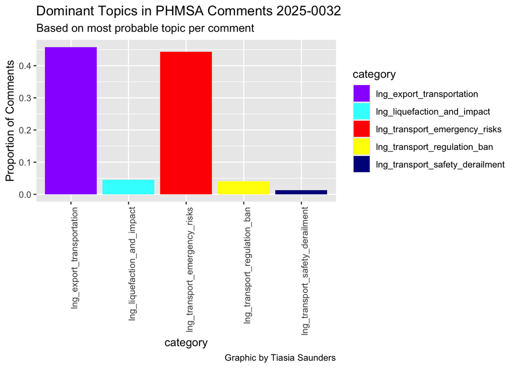

```r
dominantTopics_2025 |>
  count(category) |>
  mutate(proportion = n / sum(n)) |>
  ggplot(aes(x = category, y = proportion, fill = category)) +
  geom_bar(stat = "identity") +
  ylab("Proportion of Comments") +
  labs(
    title = "Dominant Topics in PHMSA Comments 2025-0032",
    subtitle = "Based on most probable topic per comment",
    caption = "Graphic by Tiasia Saunders"
  ) +
  scale_fill_manual(
    values = c("#9933FF", "#33FFFF", "red", "yellow", "darkblue", "lavender")
  ) +
  theme(axis.text.x = element_text(angle = 90, hjust = 1))
```